# Does the Empathy Gap Between Real and AI-Written Clinician Comments Depend on the Medical Topic?

# 1 In short

Earlier analyses showed that comments written by AI models generally show less empathy than the real clinician comments they imitate, with some exceptions. This report asks a follow-up question: **is that gap the same for every kind of medical question, or is it bigger for some topics (say, mental health) than for others (say, skin conditions)?**

To find out, every one of the 6,600 Reddit r/AskDocs threads in the study was assigned a medical topic based on the original post, and we then estimated how the real-vs-AI empathy gap changes from topic to topic. We did this with a statistical model that is deliberately cautious about small topics: it estimates each topic’s gap, but pulls estimates for topics with little data toward the overall average rather than letting a handful of threads produce a dramatic-looking result.

We also asked a second, simpler question: **do threads where cancer is involved look different from the rest?**

# 2 What we did, in plain terms

## 2.1 The comparison

Each thread is a patient’s question posted on r/AskDocs. For each thread we have the comments that real, verified clinicians wrote, and comments that 3 AI models wrote in response to the same post, using 3 different prompting strategies. In total that is 8,625 real comments and 128,653 AI-written ones.

Each comment was rated by three trained classifiers for three kinds of empathy: **emotional reactions** (acknowledging how the patient feels), **interpretations** (showing the patient’s situation was understood), and **explorations** (asking about or probing the patient’s experience). Each rating is “none”, “weak”, or “strong”. Comments with some empathy are fairly rare, so the models below ask a simple yes/no question: *does this comment show this kind of empathy?*

## 2.2 Assigning a topic to every thread

A language model read the title and text of each opening post and chose one of 17 medical disciplines (for example Dermatology, Cardiovascular, Psychiatry and mental health). The label belongs to the **thread**, so every comment under a post, real or AI-written, carries that post’s topic.

Two of the 17 labels are catch-alls, “Medical; other” and “Nonmedical”. They describe what a post is *not* rather than what it is, so we left them out of the topic analysis. Table 2.1 shows how many threads fall in each topic. 6 topics are small (under 5% of threads); they stay in the analysis, but are flagged as exploratory.

Table 2.1: Threads per topic and how each topic is used.

| Topic | Threads | Share of threads | Role in the topic analysis |
| --- | --- | --- | --- |
| Dermatology | 715 | 10.8% | Included |
| Gastroenterology | 711 | 10.8% | Included |
| Genitourinary and reproductive health | 695 | 10.5% | Included |
| Psychiatry and mental health | 596 | 9.0% | Included |
| Infectious diseases | 572 | 8.7% | Included |
| Neurology | 525 | 8.0% | Included |
| Cardiovascular | 498 | 7.5% | Included |
| Endocrinology, nutrition, and metabolism | 439 | 6.7% | Included |
| Musculoskeletal and connective tissue conditions | 362 | 5.5% | Included |
| Medical; other | 361 | 5.5% | Left out (residual category) |
| Hematology and immunology | 326 | 4.9% | Included, exploratory (< 5% of threads) |
| Otolaryngology | 281 | 4.3% | Included, exploratory (< 5% of threads) |
| Pulmonology | 174 | 2.6% | Included, exploratory (< 5% of threads) |
| Neoplasms | 173 | 2.6% | Included, exploratory (< 5% of threads) |
| Ophthalmology | 69 | 1.0% | Included, exploratory (< 5% of threads) |
| Dentistry | 64 | 1.0% | Included, exploratory (< 5% of threads) |
| Nonmedical | 39 | 0.6% | Left out (residual category) |

## 2.3 Making a fair comparison

Two features of the data would distort a naive comparison.

- **Comments from the same thread are not independent.** A thread about a frightening symptom might draw more empathetic replies of both kinds. The model accounts for this by giving every thread its own baseline.
- **There are more AI comments than real ones in a thread.** The AI models wrote one reply for every comment on a thread, but only some of those comments came from verified clinicians. Without correction, threads with many comments would count for more on the AI side than on the real side. We fixed this by *weighting* rather than discarding data: a real comment counts as 1, and when a model wrote more comments for a thread than there are real ones, each of its comments counts for a fraction, so that for every thread both sides carry the same total weight. For example, if a thread has 2 real comments and one model wrote 8, each of those 8 counts for 0.25.

We looked at two other options before choosing this. Dropping AI comments that were unusually long or short removed comments that showed empathy unevenly across the models, and left some threads without enough AI comments to match the real ones. Randomly keeping only as many AI comments as real ones made the results depend noticeably on which comments happened to be kept. Weighting avoids both problems.

## 2.4 Letting the gap differ by topic

For each type of empathy, the model estimates:

1. how much less likely an AI comment is to show empathy than a real one, on average (the **gap**), and
2. how much each topic moves that gap up or down (the topic’s **shift**).

The topic shifts are *partially pooled*: a topic with many threads gets an estimate that is mostly its own, while a topic with few threads is pulled toward the average. This is the main protection against over-reading small topics, and it means we do not need a separate cut-off or a correction for looking at many topics.

The question about cancer is handled by a separate, simpler model that compares the gap in the 518 cancer-related threads with the gap in all other threads.

## 2.5 How to read the numbers

Everything is reported as an **odds ratio** with a 95% credible interval.

- A *gap* below 1 means AI comments have lower odds of showing empathy than real ones. A gap of 0.5 means the odds are halved.
- A *shift* is relative to the average topic. Below 1 means the gap is *larger* than average in that topic; above 1 means *smaller*.
- `pd` is the probability, given the data and model, that the effect points the way we report it. It is not a p-value. We call a result **credible** only when `pd` is above 0.975 *and* the interval excludes 1.

# 3 What to keep in mind

- **The topic labels are imperfect.** The labelling model agrees with a reference set of 200 posts about 77% of the time, and the reference set was itself mostly produced by language models. Roughly one label in four may be off. Errors in a grouping variable like this blur real differences, so a finding of “no topic differences” is weaker evidence than it sounds.
- **Topic comes from the post, not the comment.** A reply that wanders to a different subject still carries the original post’s topic.
- **The gap is an average over the AI models and strategies.** These differ a lot from one another, and for some empathy types they do not even point the same way (for Interpretations, Grok’s comments score above the real ones while Gemini’s and OpenAI’s score below), so the average can look small where individual models differ strongly. The topic shift is assumed to be the same for all of them; we have not tested whether topics affect some models more than others.
- **Empathy ratings come from classifiers, not people.** All comparisons are about what the classifiers detect.
- **Weighting is an approximation.** It targets the same quantity as repeated random sampling would, but the reported uncertainty is only approximate.
- **Small topics are exploratory.** Even with pooling, topics with few threads give wide intervals.

# 4 Methods

## 4.1 Data

The analysis uses all 137,278 rated comments from 6,600 threads (8,625 real, 128,653 synthetic), with no outlier exclusion and no subsampling. Synthetic comments come from Gemini, OpenAI and Grok, each under three prompting strategies: DG (discourse generation), SAG (single advice generation) and SAGII (SAG with incremental information). That gives nine synthetic groups plus the real group.

Empathy labels (0 = none, 1 = weak, 2 = strong) for emotional reactions (ER), interpretations (IP) and explorations (EX) come from three fine-tuned RoBERTa bi-encoder classifiers following the EPITOME framework. The binary outcome is `label >= 1` for ER. For IP and EX the classifiers never output label 1 in this data, so `label >= 1` and `label == 2` coincide. The three-level ER outcome used in the main Bayesian models is not used here: split by topic its strong-empathy cell is nearly empty for some models (for Grok, a handful of comments out of about 14,000), so the binary collapse is used instead.

## 4.2 Topic labels

Labels were produced by the collaborators’ pipeline (`classify_topics.py`): an LLM (gemini-2.5-pro, temperature 0) assigns each opening post to one of 17 disciplines from the taxonomy in Chan et al. (JMIR Formative Research 2025; 9:e55309). There is one label per thread, joined on `submission_id`; all 6,600 threads are labelled. The `discipline` column is used for every thread (not the reference-sample labels), so that measurement is uniform across the corpus. The file used has md5 453163a8a882405ab4bd8d878c53bfee (`input/topics/SOURCE.txt` records its origin).

Validation against a 200-post reference sample: production-model agreement 0.770; agreement between the two LLM annotators who built the reference 0.795 (Cohen’s $\kappa$ = 0.779), with a human adjudicating their disagreements. The reference is therefore mainly inter-model consensus.

The topic models use the 15 substantive disciplines (6,200 threads). “Medical; other” and “Nonmedical” are excluded from them but kept in the other analyses. Topics with under 5% of threads (6 of the 15) are flagged exploratory in the outputs but remain in the model, where partial pooling governs their estimates.

## 4.3 Response weights

Let $n_c$ be the number of synthetic comments in a (thread, model, method) cell and $r$ the thread’s number of real comments. A real comment has weight 1 and a synthetic comment has weight $w = \min(1, r / n_c)$. The synthetic weights sum to 77,603, which is exactly what random per-thread subsampling to $\min(n_c, r)$ would retain, and the expected subsampled log-likelihood equals the weighted one. Weights are computed on all threads before any topic filtering, so excluding threads does not change the weights of the rest. In `brms` the weights multiply each observation’s log-likelihood, giving a pseudo-likelihood: point estimates target the subsampling average, but posterior widths are approximate.

## 4.4 Models

Fitted separately for ER, IP and EX with a Bernoulli likelihood and logit link, $y_i$ the binary outcome, $s_i$ an indicator for a synthetic comment, $g(i)$ the comment’s group (real or one of nine model-by-method cells), $t(i)$ its thread’s topic and $p(i)$ its thread:

**Model C (topic moderation).**
$$\operatorname{logit} P(y_i = 1) = \alpha + \beta_{g(i)} + \gamma\,\log(\text{length}_i) + u_{t(i)} + v_{t(i)}\,s_i + a_{p(i)}$$
with $(u_t, v_t) \sim \mathcal N(0, \Sigma)$ over topics and $a_p \sim \mathcal N(0, \sigma_p^2)$ over threads. The $\beta_g$ are the group coefficients as in the main analysis. A topic’s gap on the log-odds scale is the mean of the nine synthetic $\beta_g$ plus $v_t$; its *shift* is $v_t$; both are exponentiated to odds ratios. The posterior of the SD of $v_t$ is the direct measure of how much the gap varies by topic. A random slope on the single indicator $s$ (rather than on the nine groups) keeps the covariance structure small enough to estimate from 15 topics.

**Model D (cancer relevance).**
$$\operatorname{logit} P(y_i = 1) = \alpha + \beta_{g(i)} + \delta\,c_{p(i)} + \theta\,s_i c_{p(i)} + \gamma\,\log(\text{length}_i) + a_{p(i)}$$
where $c$ indicates a cancer-relevant thread. The gap is the mean of the synthetic $\beta_g$ for non-cancer threads and that plus $\theta$ for cancer threads; $\theta$ is the moderation. The 2 threads with no cancer flag are dropped from this model only.

## 4.5 Priors and sampling

Fixed effects: Normal(0, 2.5), the standard weakly-informative default for logistic models (Gelman et al., 2008); this also keeps estimates finite in sparse cells. Intercept and the thread SD: Student-$t$(3, 0, 2.5). Topic SDs (intercept and slope): Normal(0, 1) truncated at zero, tighter because 15 topics carry little information about a variance. The topic correlation uses `brms`’ default LKJ(1) prior.

Models are fitted with `brms` (Stan via `cmdstanr`): 4 chains of 2,000 iterations (1,000 warmup), 4 threads per chain, `adapt_delta` = 0.95, seed 20260101. A fit is accepted as converged when max $\hat R < 1.01$, the minimum effective-sample-size ratio exceeds 0.1, and there are no divergent transitions; this is reported per fit. The Interpretations topic model (Model C) was rerun with 4,000 iterations because its max $\hat R$ was 1.0106 at 2,000; this brought it to 1.003 but left one divergent transition in 8,000 draws, and its estimates and the set of credible topics were unchanged. Multithreaded summation makes draws non-reproducible from the seed alone, so the fitted models are saved to disk (`models_bayesian/`) together with software versions (`run_metadata_topic.txt`) and reproducibility rests on those.

## 4.6 Reporting

For each quantity: posterior median odds ratio, 95% highest-density interval, and $pd = \max\{P(\theta > 0), P(\theta < 0)\}$ on the log-odds scale. “Credible” requires $pd > 0.975$ and an interval excluding 1. No frequentist multiplicity correction is applied; topic-level estimates are partially pooled instead. Topics under 5% of threads are labelled exploratory. Code: `3h_topic_moderation_models.R`.

## 4.7 Known limitations of the design

- Misclassification of the topic moderator attenuates moderation estimates toward zero; no correction for it is applied.
- The topic shift is common to all nine synthetic groups. Whether it differs across models or methods is a separate model, not fitted here.
- The cancer flag is a separate construct from the “Neoplasms” topic (which also covers benign neoplasms and requires a clinician or test to have raised the concern).
- Weighted posterior intervals are approximate; a subsampling sensitivity check is planned separately.

# 5 Results

## 5.1 Model checks

5 of 6 fits met every convergence criterion; the exception is: Interpretations topic model (1 divergent transition).

## 5.2 Does the gap vary by topic?

Table 5.1 gives the average gap for each empathy type and how much it moves from topic to topic. The spread is the standard deviation of the topic shifts on the log-odds scale; a spread of $s$ means a typical topic’s gap is a factor of $e^{s}$ above or below the average.

Table 5.1: Average real-vs-AI gap and how much it varies across topics.

| Empathy type | Average gap, odds ratio (95% CrI) | Spread across topics, SD (95% CrI) | Typical factor |
| --- | --- | --- | --- |
| Emotional Reactions | 0.089 (0.075-0.10) | 0.22 (0.10-0.40) | x1.25 |
| Interpretations | 0.83 (0.67-1.03) | 0.33 (0.16-0.55) | x1.39 |
| Explorations | 0.057 (0.043-0.076) | 0.47 (0.29-0.73) | x1.60 |

The interval for the spread lies clearly above zero (lower end above 0.05) for 3 of 3 empathy types, so the gap does differ across topics, by an amount that depends on the empathy type. Gaps below 1 mean AI comments have lower odds of showing empathy than real ones. For Interpretations the average gap’s interval includes 1: on average AI comments are roughly on par with real ones there, and individual topics fall on either side.

## 5.3 Which topics differ?

Figure 5.1 shows every topic’s gap; filled points are topics whose shift from the average is credible.

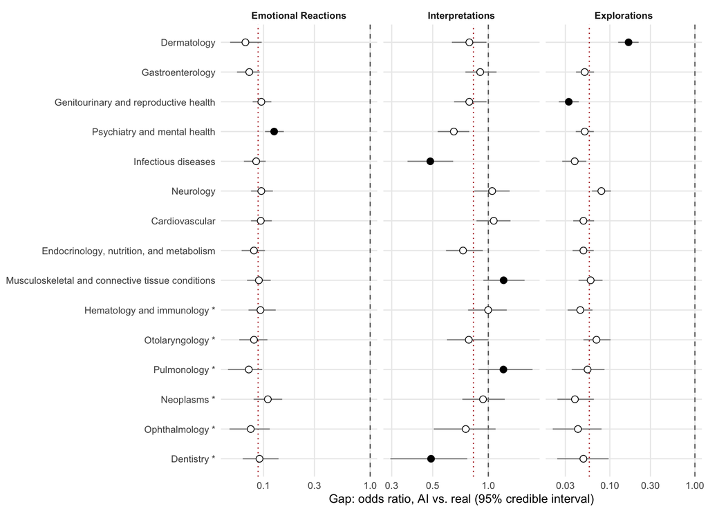

Figure 5.1: Real-vs-AI gap by topic (odds ratio, log scale; below 1 = AI comments less likely to show empathy). Filled points: credible shift from the average. Starred topics have under 5% of threads (exploratory). Dashed line: no gap; dotted line: average over topics.

7 of the 45 topic-level shifts are credible (Table 5.2). Shifts above 1 mean the gap is smaller than average in that topic; below 1, larger.

Table 5.2: Topics whose gap credibly differs from the average (starred topics are exploratory).

| Empathy type | Topic | Threads | Gap, OR (95% CrI) | Shift, OR (95% CrI) | pd |
| --- | --- | --- | --- | --- | --- |
| Emotional Reactions | Psychiatry and mental health | 596 | 0.13 (0.10-0.16) | 1.41 (1.12-1.79) | 0.998 |
| Interpretations | Infectious diseases | 572 | 0.49 (0.37-0.65) | 0.59 (0.42-0.80) | 1.000 |
| Interpretations | Musculoskeletal and connective tissue conditions | 362 | 1.21 (0.94-1.57) | 1.45 (1.09-1.97) | 0.997 |
| Interpretations | Pulmonology * | 174 | 1.21 (0.88-1.73) | 1.45 (1.06-2.17) | 0.993 |
| Interpretations | Dentistry * | 64 | 0.49 (0.30-0.77) | 0.59 (0.35-0.92) | 0.993 |
| Explorations | Dermatology | 715 | 0.17 (0.13-0.22) | 2.87 (1.99-4.09) | 1.000 |
| Explorations | Genitourinary and reproductive health | 695 | 0.033 (0.025-0.043) | 0.57 (0.40-0.84) | 0.998 |

These should be read as leads rather than conclusions. With 45 shifts examined, around 2 would clear a threshold like this by chance alone even if topic made no difference (partial pooling reduces this, but does not remove it). The topic labels are also noisy, which blurs real differences. Topics under 5% of threads give wide intervals and are the least trustworthy.

## 5.4 Cancer-related threads

- **Emotional Reactions:** gap 0.10 in other threads and 0.12 (0.090-0.16) in cancer-related threads. No credible difference (shift 1.21 (0.90-1.65), pd 0.893).
- **Interpretations:** gap 0.79 in other threads and 1.14 (0.83-1.54) in cancer-related threads. The gap is credibly smaller in cancer-related threads (shift 1.45 (1.06-2.00), pd 0.989).
- **Explorations:** gap 0.064 in other threads and 0.044 (0.032-0.061) in cancer-related threads. The gap is credibly larger in cancer-related threads (shift 0.69 (0.51-0.99), pd 0.983).

Here too the same caveats apply: a borderline interval (one end close to 1) is weak evidence, and the cancer flag itself comes from a language model.